# Nervový systém – analýza výsledků

Hynek Janáč

2025-07-08

Analýza kvízu **Nervový systém** z histologie dostupném [zde](https://docs.google.com/forms/d/1Oh5b-uHBWweojSWe9AhHrhWCI-IIAPQc4FbhtlKh940/edit).

## Základní statistiky

Počet účastníků testu: **152**  
Minimální možný počet bodů: **0**[^1]  
Maximální možný počet bodů: **10**  
Dosažené minimum: **1**  
Dosažené maximum: **10**  
Průměr: **7.28**  
Medián: **7**  
[Cronbachovo alfa](https://www.wikiskripta.eu/w/F%C3%B3rum:Testy/Cronbachovo_alfa): **0.557**

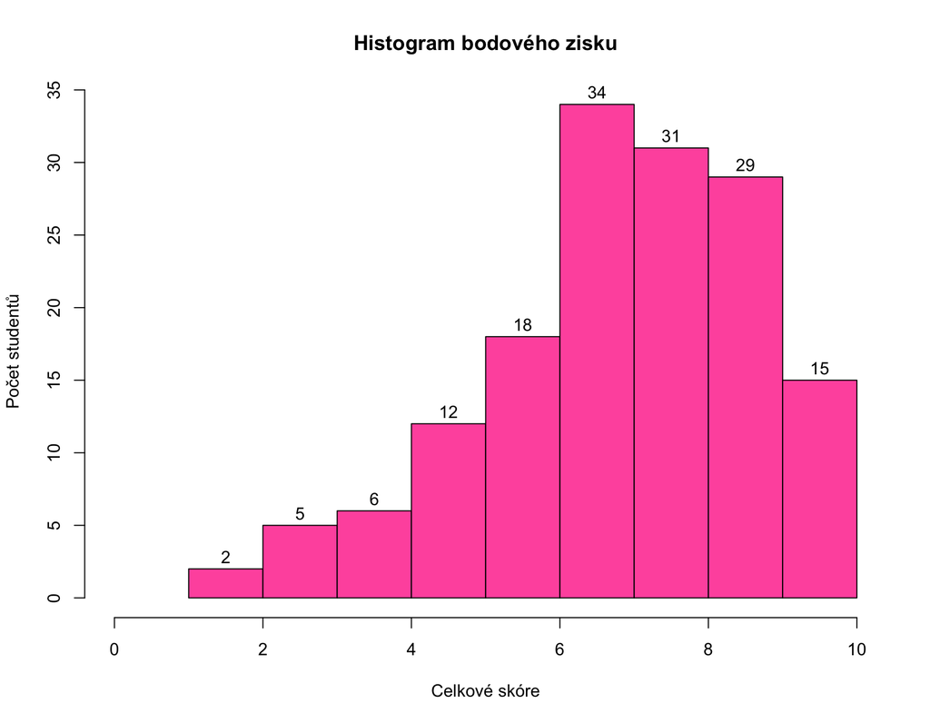

## Analýza položek

|  | Otazka | Obtiznost | DolniSkupina | StredniSkupina | HorniSkupina | ULI |
| --- | --- | --- | --- | --- | --- | --- |
| Otazka1 | Součástí hematoencephalické bariéry je také gliová membrána, které glie jsou s největší pravděpodobností zodpovědné za její udržování? | 0.888 | 0.698 | 0.954 | 0.977 | 0.28 |
| Otazka2 | Vyberte které písmeno označuje na preparátu mozečku bílou hmotu. | 0.743 | 0.372 | 0.862 | 0.932 | 0.56 |
| Otazka3 | Na vstřebávání mozkomíšního moku se převážně podílí: | 0.895 | 0.767 | 0.923 | 0.977 | 0.21 |
| Otazka4 | Na preparátu je struktura nacházející se v mozkových komorách, zodpovídá za produkci likvoru. Který typ cév se v ní bude s největší pravděpodobností vyskytovat? | 0.77 | 0.558 | 0.8 | 0.932 | 0.374 |
| Otazka5 | Která struktura NEpatří do tzv. mozečkového glomerulu? | 0.743 | 0.581 | 0.692 | 0.977 | 0.396 |
| Otazka6 | Jak jsou uspořádany dendritické stromy nervové buňky na obrázku? | 0.77 | 0.535 | 0.831 | 0.909 | 0.374 |
| Otazka7 | U které buňky v mozečku se dá imunohistochemicky prokázat GFAP (Gliální fibrilární acidický protein)? | 0.757 | 0.512 | 0.754 | 1 | 0.488 |
| Otazka8 | Následující schéma ukazuje? | 0.684 | 0.349 | 0.738 | 0.932 | 0.583 |
| Otazka9 | Na detailu preparátu mozkové kůry, vyberte které písmeno označuje lamina pyramidalis externa. | 0.322 | 0.093 | 0.215 | 0.705 | 0.612 |
| Otazka10 | Buňky označené na obrázku budou s největší pravděpodobností? | 0.711 | 0.419 | 0.708 | 1 | 0.581 |

### Difficulty-discrimination plot

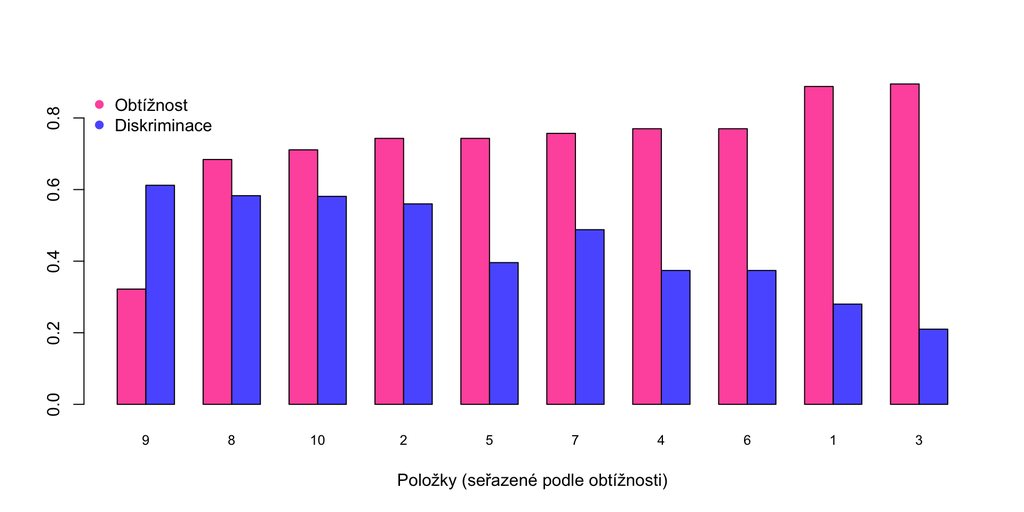

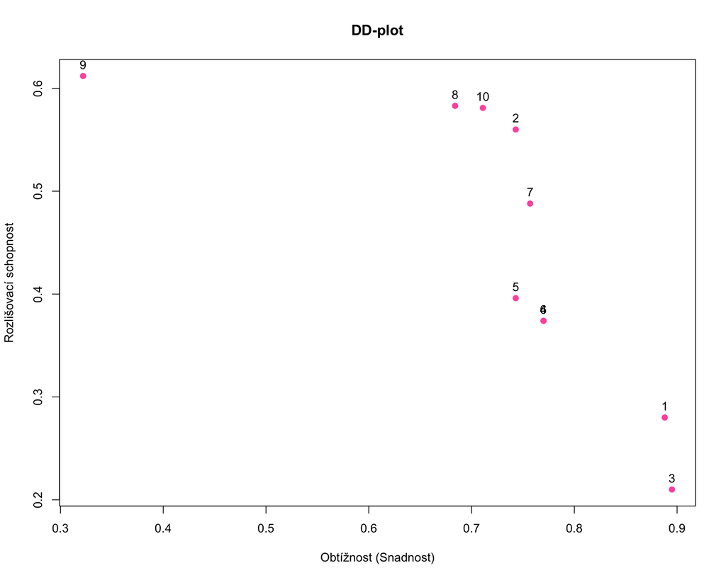

### Analýza jednotlivých položek

#### Položka č.1

**Zadání položky:** Součástí hematoencephalické bariéry je také gliová membrána, které glie jsou s největší pravděpodobností zodpovědné za její udržování?

**Možnosti:** *A:* astrocyty *B:* oligodendrocyty *C:* mikroglie *D:* Bergmanova glie

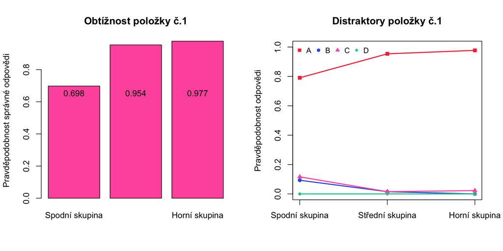

#### Položka č.2

**Zadání položky:** Vyberte které písmeno označuje na preparátu mozečku bílou hmotu.

**Možnosti:** *A:* A *B:* B *C:* C *D:* D

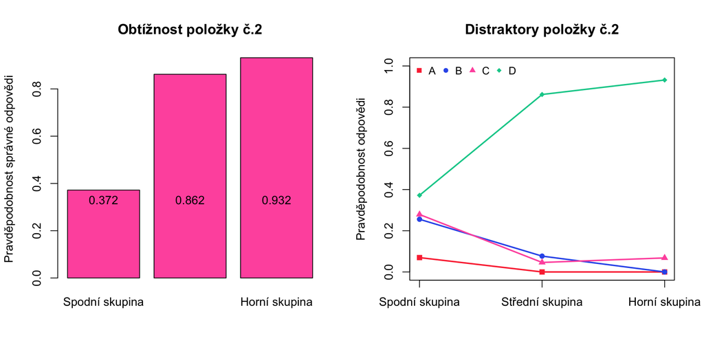

#### Položka č.3

**Zadání položky:** Na vstřebávání mozkomíšního moku se převážně podílí:

**Možnosti:** *A:* buňky plexus choroideus *B:* arachnoidové klky *C:* astrocyty *D:* klky pia mater

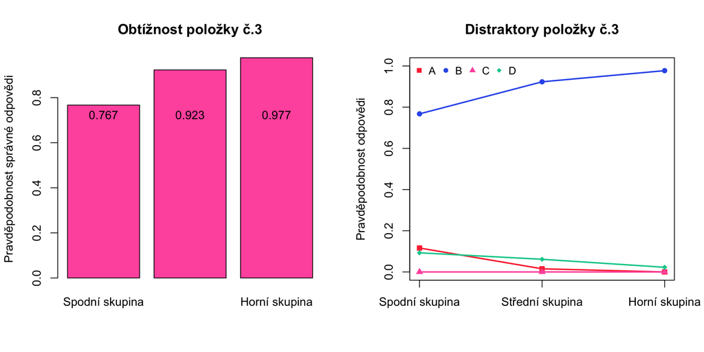

#### Položka č.4

**Zadání položky:** Na preparátu je struktura nacházející se v mozkových komorách, zodpovídá za produkci likvoru. Který typ cév se v ní bude s největší pravděpodobností vyskytovat?

**Možnosti:** *A:* kapiláry s fenestrovaným endotelem *B:* sinusoidní kapiláry *C:* kapiláry se souvislým endotelem *D:* jedná se avaskulární tkáň

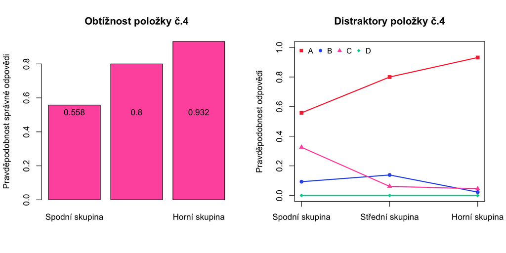

#### Položka č.5

**Zadání položky:** Která struktura NEpatří do tzv. mozečkového glomerulu?

**Možnosti:** *A:* Golgiho buňka *B:* Granulární buňka *C:* mechové vlákno *D:* Košíčková buňka

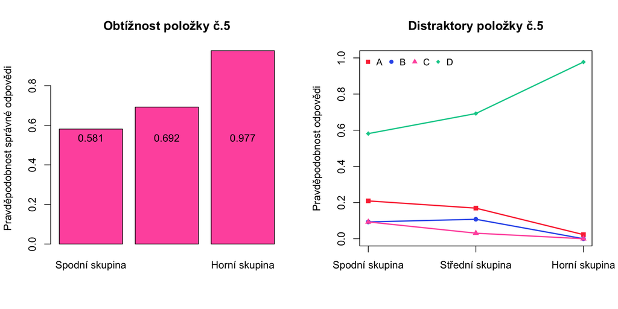

#### Položka č.6

**Zadání položky:** Jak jsou uspořádany dendritické stromy nervové buňky na obrázku?

**Možnosti:** *A:* Dendritické stromy jsou orientovány paralelně k povrchu kůry mozečku. *B:* Dendritické stromy jsou orientovány kolmo k povrchu kůry mozečku. *C:* Dendritické stromy jsou rozvětvené ve všech směrech bez specifické orientace. *D:* Dendritické stromy jsou spirálovitě rozvětvené ve všech směrech

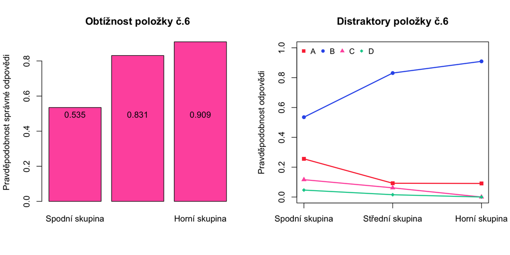

#### Položka č.7

**Zadání položky:** U které buňky v mozečku se dá imunohistochemicky prokázat GFAP (Gliální fibrilární acidický protein)?

**Možnosti:** *A:* Bergmanova glie *B:* Košíčkovitá buňka *C:* Golgiho buňka *D:* Hvězdicovitá buňka

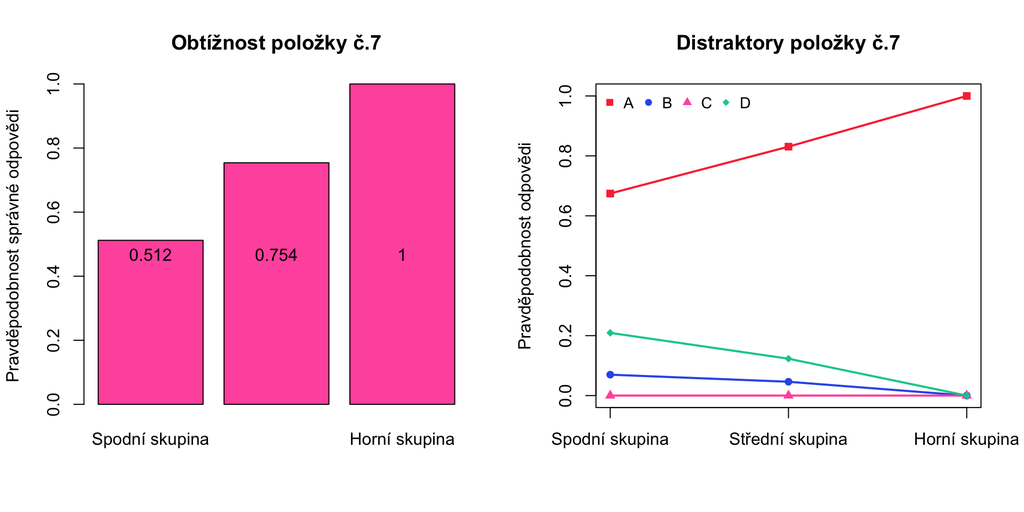

#### Položka č.8

**Zadání položky:** Následující schéma ukazuje?

**Možnosti:** *A:* cytoarchitektoniku neokortexu *B:* myeloarchitektoniku neokortexu *C:* cytoarchitektoniku allokortexu *D:* myeloarchitektoniku allokortexu

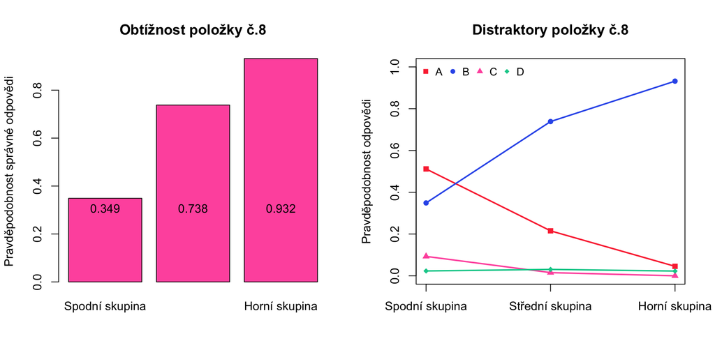

#### Položka č.9

**Zadání položky:** Na detailu preparátu mozkové kůry, vyberte které písmeno označuje lamina pyramidalis externa.

**Možnosti:** *A:* A *B:* B *C:* C *D:* D

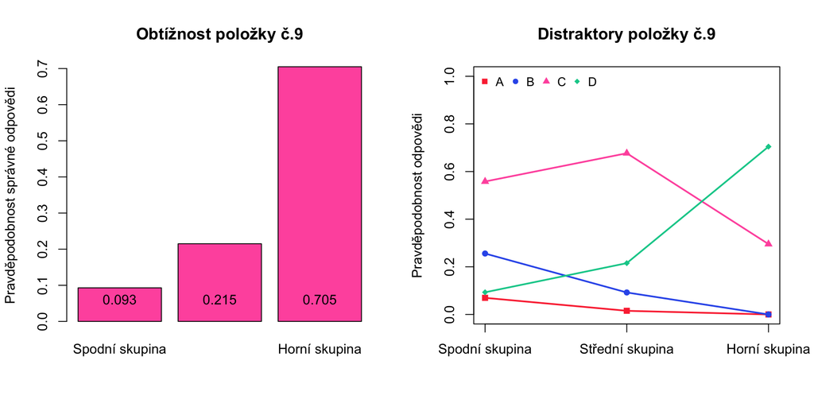

#### Položka č.10

**Zadání položky:** Buňky označené na obrázku budou s největší pravděpodobností?

**Možnosti:** *A:* pseudounipolární T neurony *B:* alfa-motoneurony *C:* intrafusální vlákno s jaderným vakem *D:* y-motoneurony

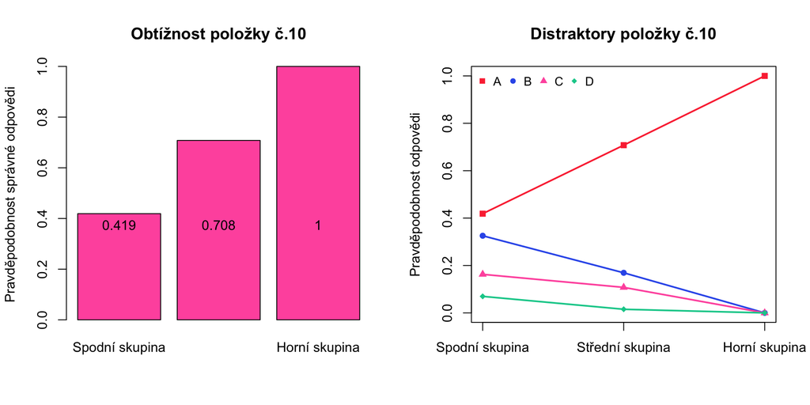

# Odkazy a poznámky

- Analýza byla provedena pomocí programovacího jazyka R.
- [Testování při výuce medicíny](https://www.wikiskripta.eu/w/F%C3%B3rum:Testy)
- ŠTUKA, Čestmír a Martin VEJRAŽKA, 2022. Testování a hodnocení studentů na VŠ. Karolinum Press. ISBN 978-80-246-5107-1.
[^1]: Odpovědi, které dosáhli celkově 0 bodů byly vyřazeny z analýzy, neboť většinou vzniknou nevyplněním testu než-li neznalostí.